# Worldbank Tobacco Analysis

Leonie Mertes

2025-01-15

## Introduction

This analysis explores the relationship of prevalence of current tobacco use (% of adults) prevalence to GDP per capita. Therefore we analyse the following leading question:  
1. How does GDP per capita relate to the prevalence of current tobacco use (% of adults)?

### 1. Tobacco Prevalence and GDP  
Check how many NA’s in tobacco variable each Year (excluding years existing only of NA’s)

```
## # A tibble: 7 × 2
##    Year num_na
##   <int>  <int>
## 1  2000      1
## 2  2005      1
## 3  2010      1
## 4  2015      1
## 5  2018      1
## 6  2019      1
## 7  2020      1
```

Knowing there are only 25 countries to investigate, we only have data of the Years 2000, 2005, 2010, 1015, 1018, 2019 and 2020 on percentage of tabacco usage in the adult population of all 24 countries (excluding Aruba). We again adjust our dataframe.

To take a look at the grouping of our data by tobacco usage, we will display a plot of the most recent data in Year 2020.

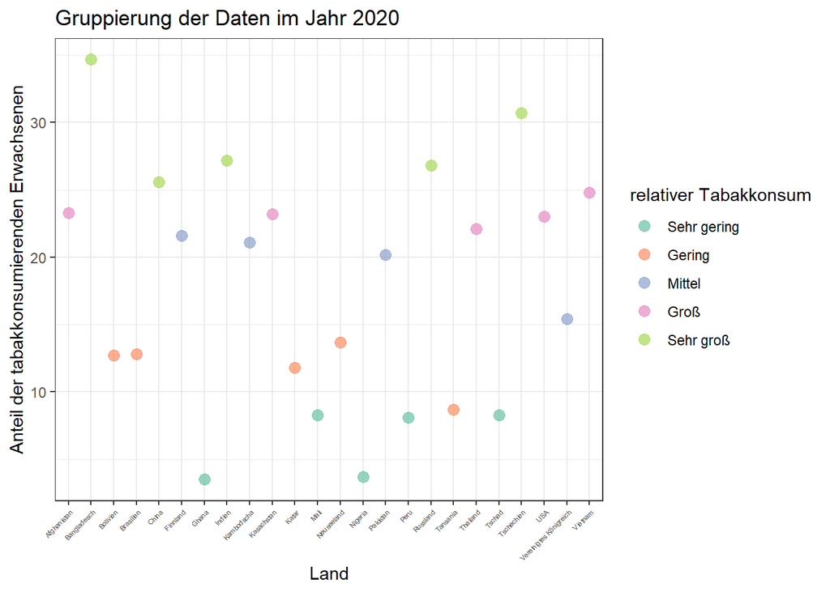

For an overview we take a look at the Comparison of tobacco usage and GDP in 2020. Therefore we group by the relative tobacco usage.

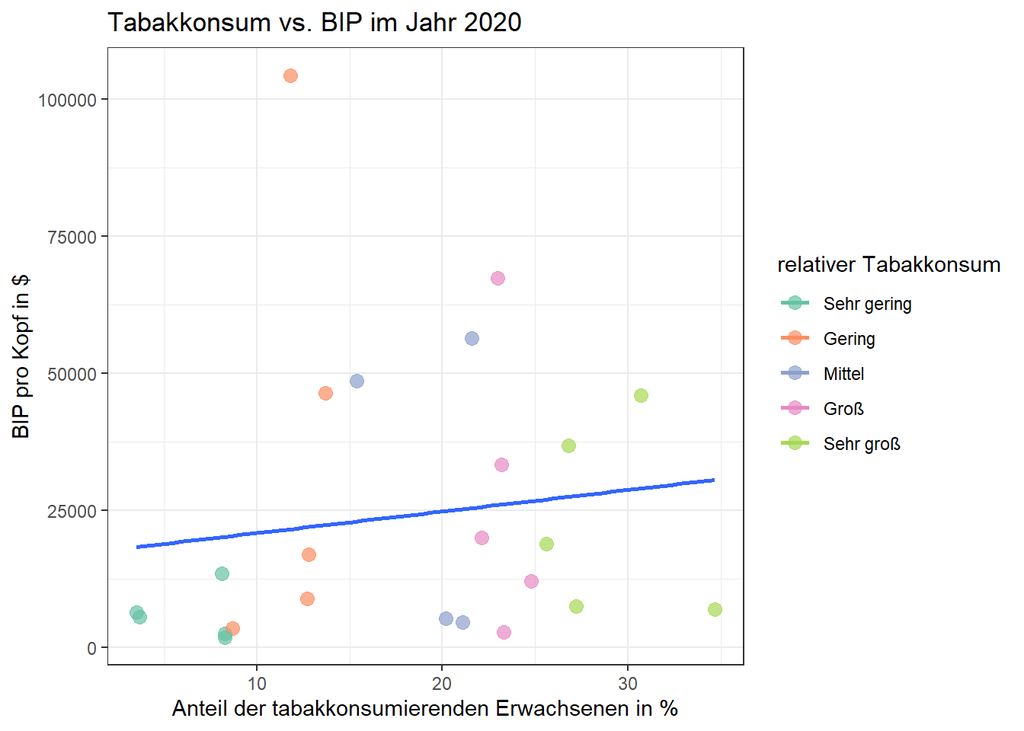

Now we view only one dot per category of relative tobacco usage.

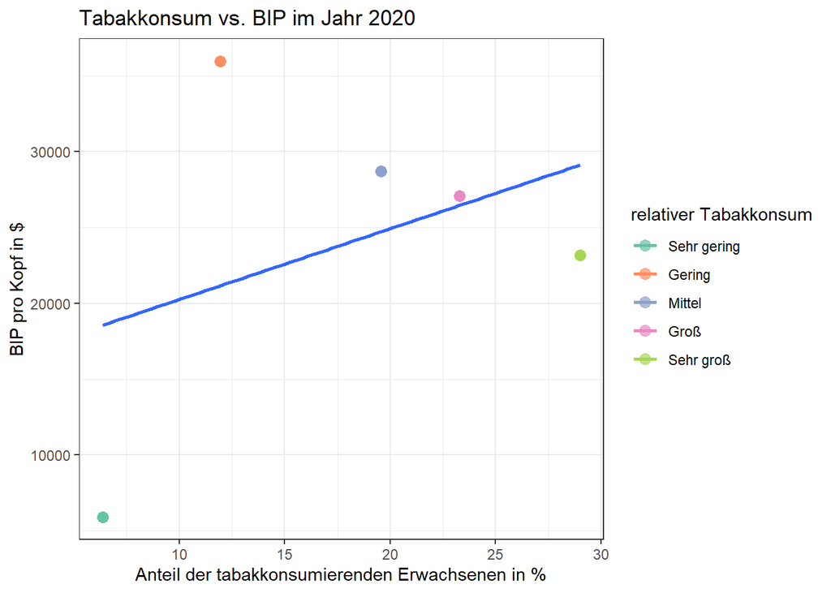

Now take a look of the coherence of the variables without our extreme value of the group “Very Low”.

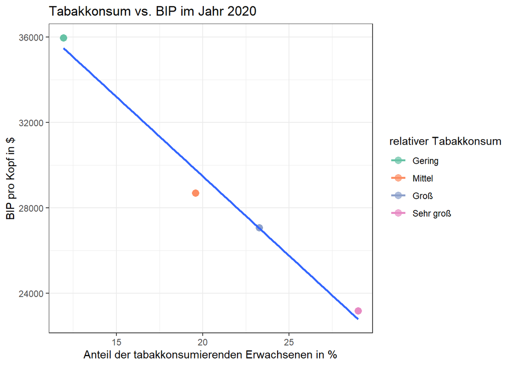

To get a better overview we take a look at all years. First only on years we have data of their tobacco consumption on.

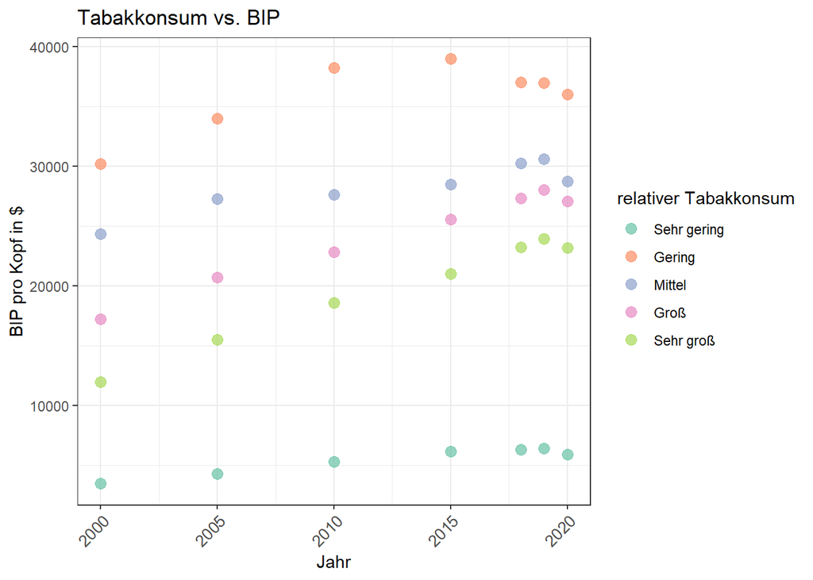

Now over all years we have data on their countries BIP.

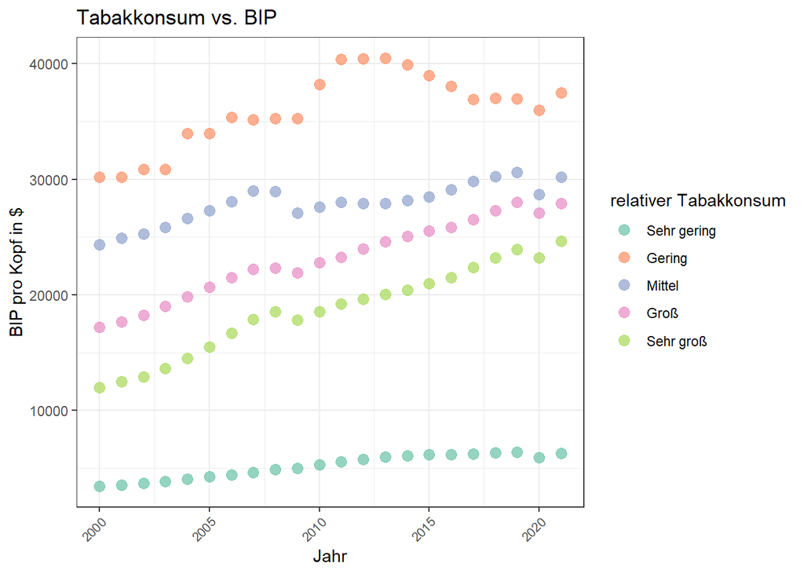

But maybe better facett over year to show better the coherence of BIP and tobacco consumption.

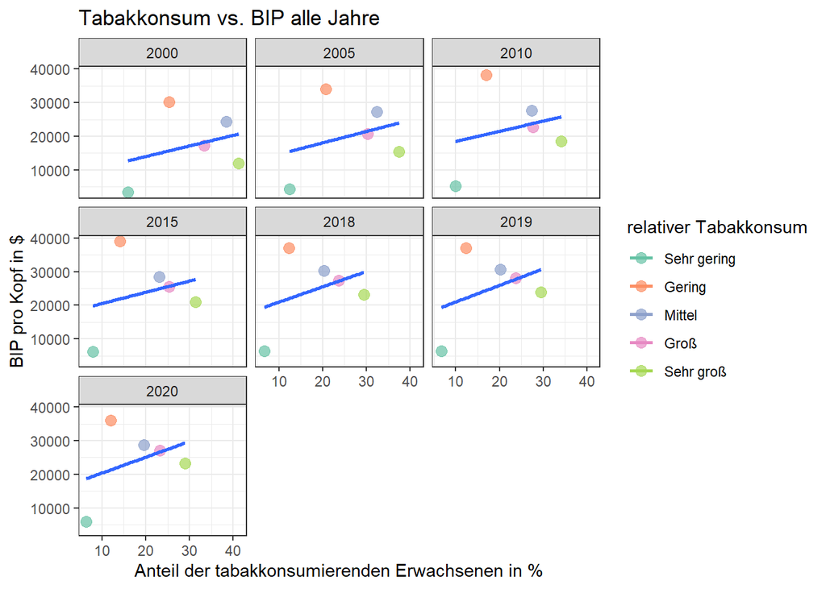

Hier sehen wir, dass die Gruppierung nicht für jedes Jahr angebracht ist. Später wollen wir die Daten für jedes Jahr neu gruppieren.  
Nun aber nochmal ohne unser lineares Modell, da durch den Wert für unser sehr niedrigen Tabbakkonsum dieses nicht geeignet ist.

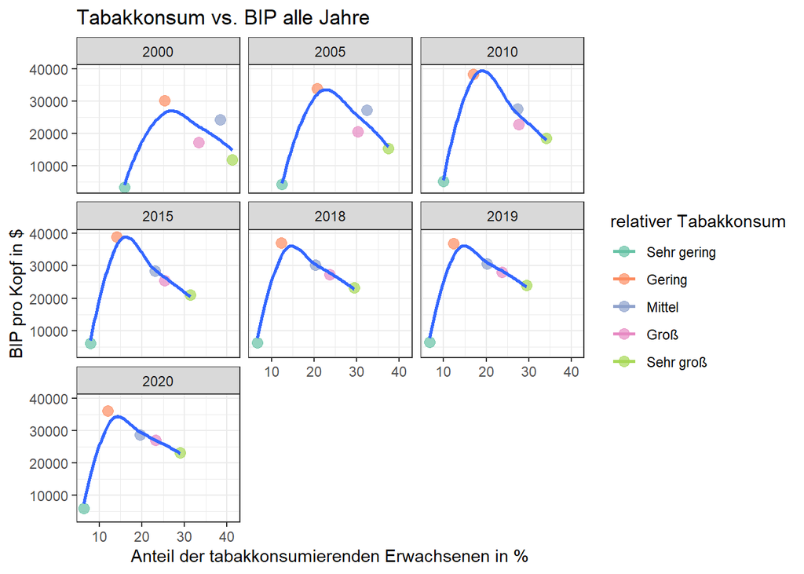

Wenn wir nun für jede Gruppe alle Länder anzeigen lassen, sieht der Plot so aus:

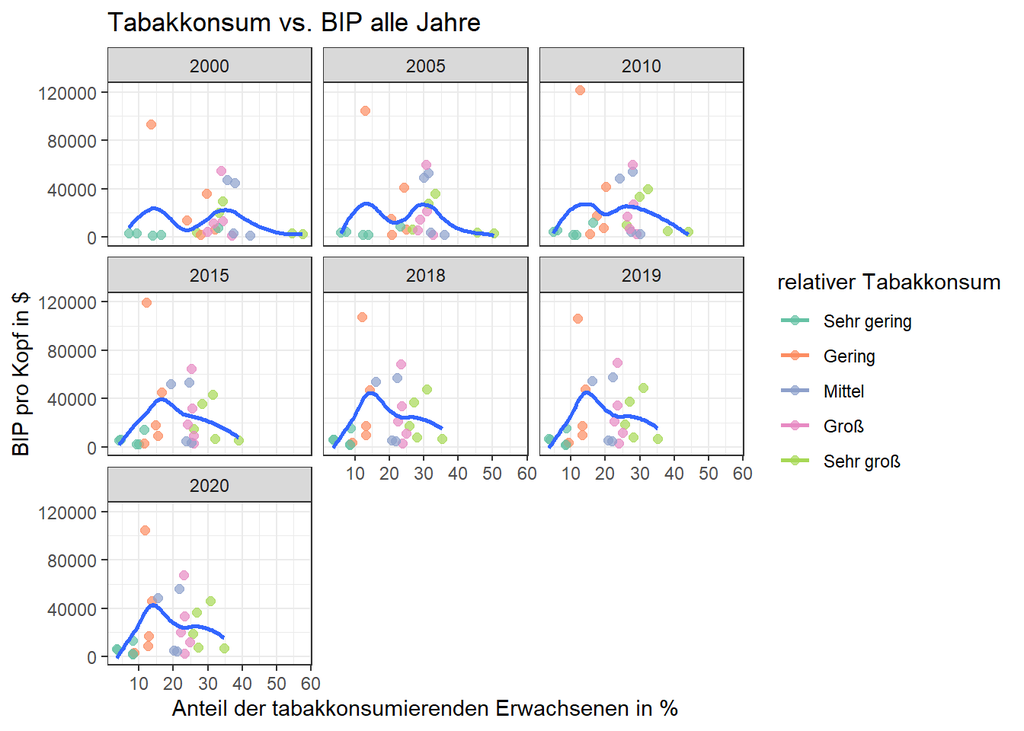

Hier fällt erneut auf, dass der relative Tabakkonsum nicht immer gut eingeordnet ist, da Gruppen mit (eingeordnet) weniger Tabakkonsum tatsächlich teilweise mehr Tabak konsumieren. Hier sollte man sich überlegen, ob es nicht besser ist die Gruppierung für jedes Jahr neu zu bestimmen. Dieses Ergebnis wollen wir dann in einem Barplot festhalten.  
Hier nun also erst mit der allgemeineren Gruppierung:

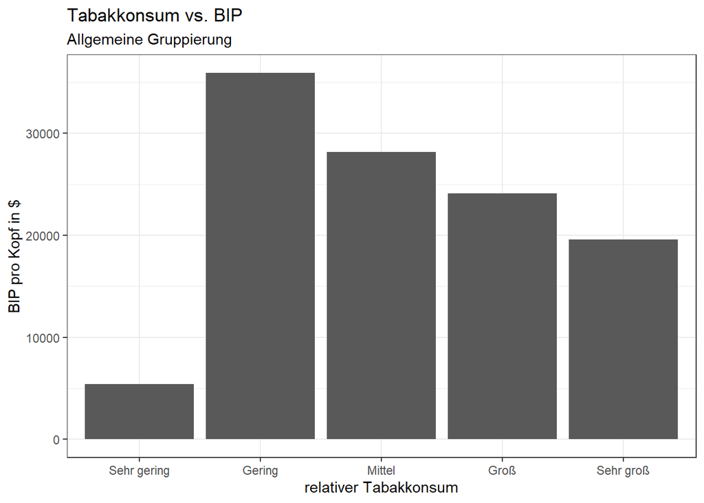

Und nun mit neuer Gruppierung der Daten:

Hierzu nun erst der nach Jahr gefacettete Dotplot:

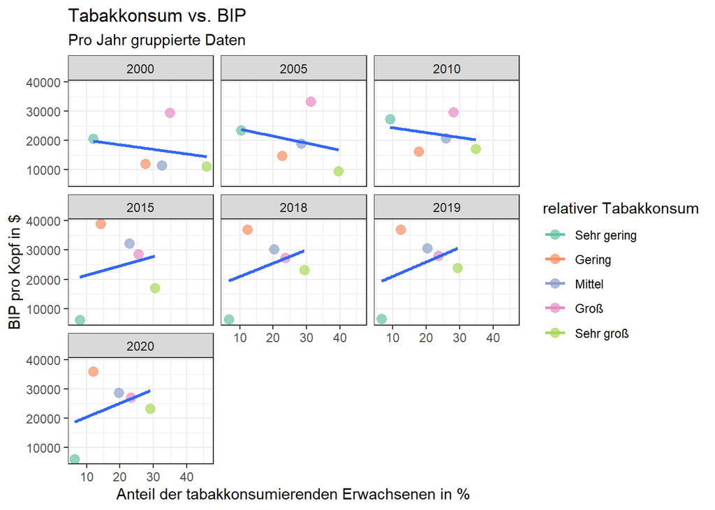

Und nun mit nicht-linearer smooth line:

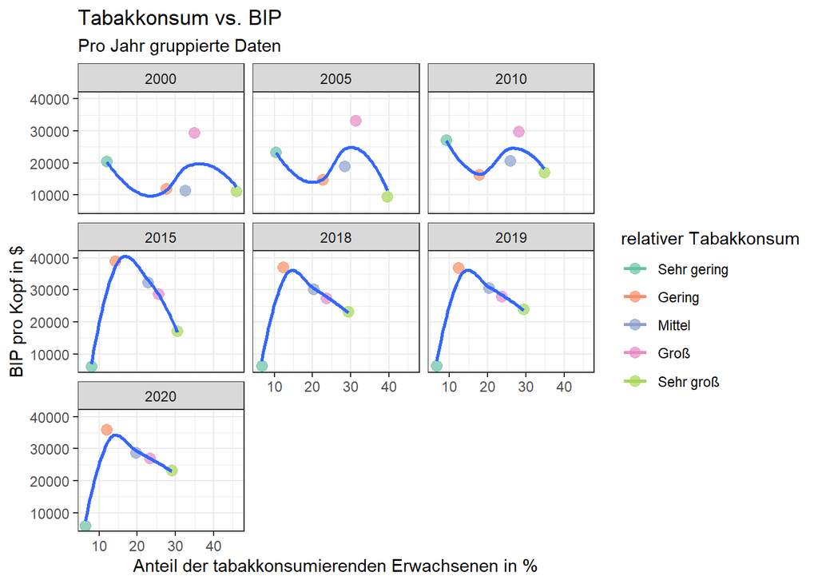

Auffällig ist, dass anders als bei den allgemein gruppierten Daten (über den Durchschnitt des Tabakkonsums eines Landes) hier nun die Länder mit relativ gesehen sehr niedrigem Tabakkonsum ein viel höheres BIP haben, als aus der vorherigen Gruppierung hervorgeht. Demnach ist es durchaus sinnvoll, die Daten jährlich neu zu gruppieren, wenn die Zugehörigkeit zu einer bestimmten Gruppe eines Landes sich über die Jahre ändern kann.  
Und nun mit Datenpunkt pro Land:

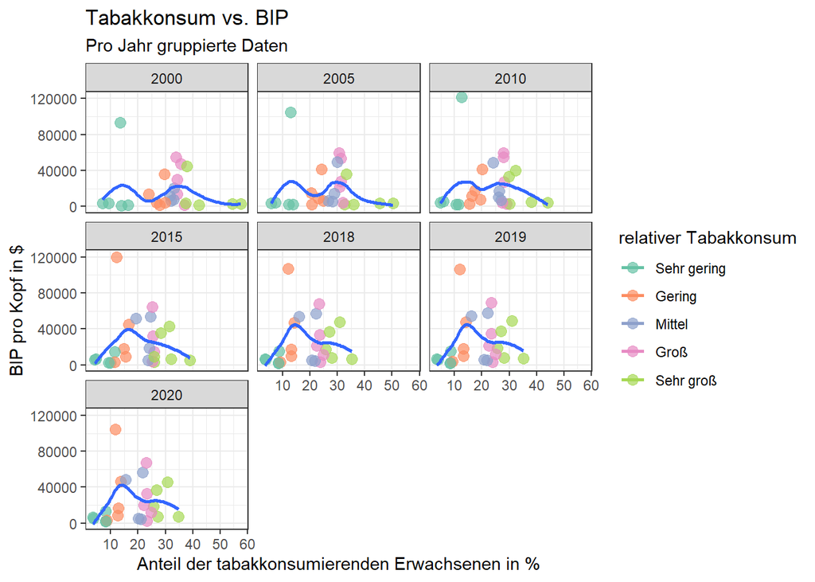

Hier sieht man nun deutlich, wie der Ausreißer einer anderen Gruppe zugeordnet wurde für die Jahre 2000-2010 und somit, warum unsere Daten nun andere Zusammenhänge zeigen.  
Und nun im Barplot:

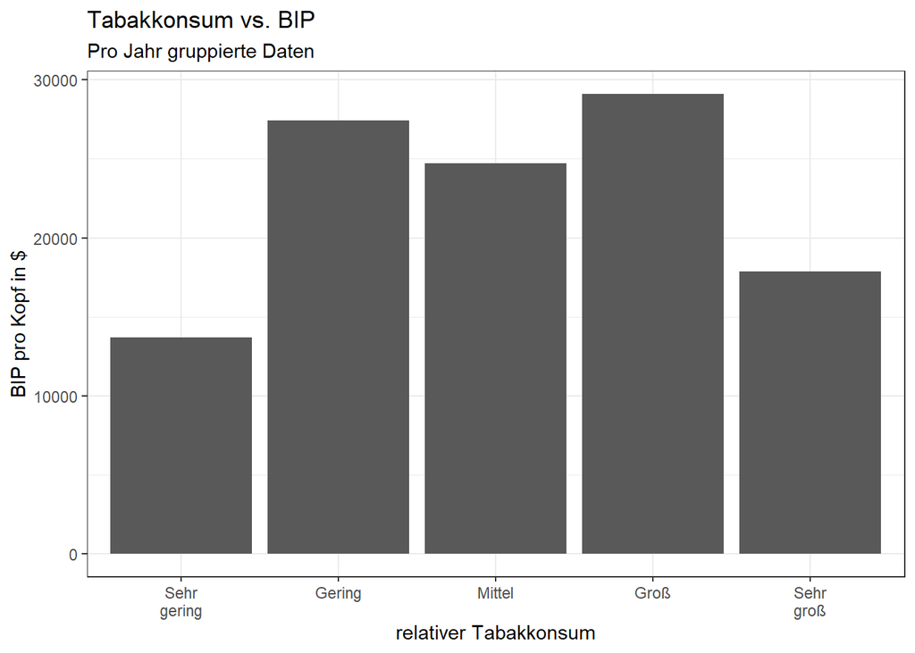

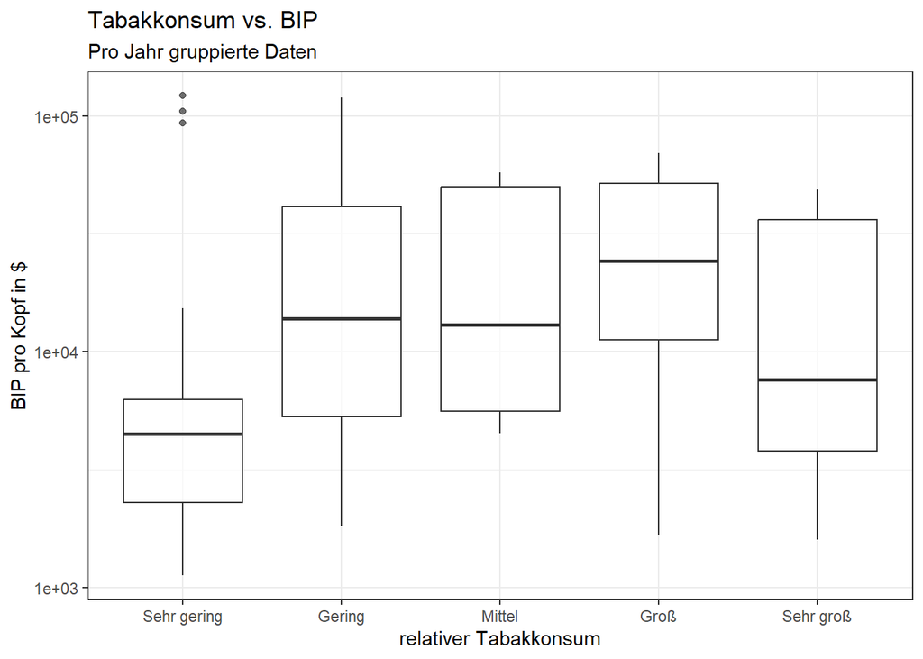

Hier nochmal nach Jahr facetiert:

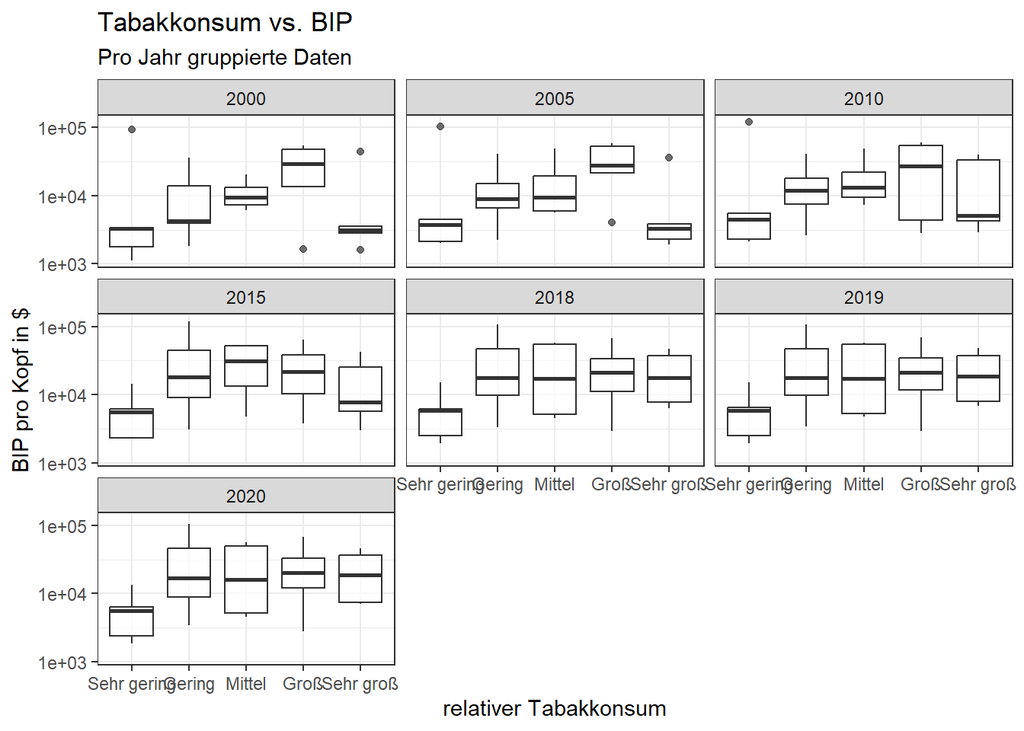

Hier Barplots facettiert nach jahr, wobei nach Tabakdurchschnittskonsum gruppiert wurde:

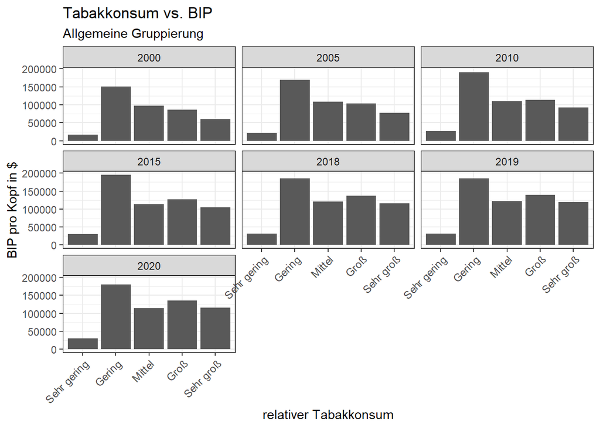

Und nun Barplots facettiert nach Jahr, wobei jedes jahr neu nach Tabakkonsum gruppiert wurde:

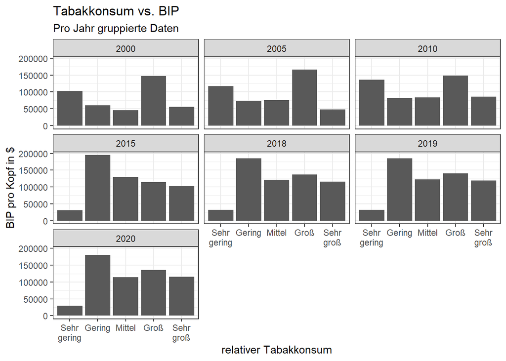